# Analisis Kategori Film Paling Menguntungkan pada Database Sakila

Stella Chelsy Renida - M0725020

2026-05-26

# 1 IMPORT LIBRARY

```r
library(odbc)
library(DBI)
library(ggplot2)
library(dplyr)
```

# 2 PENDAHULUAN

## 2.1 Latar Belakang

Perkembangan teknologi informasi menyebabkan perusahaan semakin bergantung pada data dalam pengambilan keputusan bisnis. Salah satu bentuk pemanfaatan data adalah melalui analisis transaksi pelanggan untuk mengetahui pola bisnis yang terjadi.

Database Sakila merupakan database simulasi rental film yang dikembangkan oleh MySQL sebagai media pembelajaran pengelolaan database.

Pada proyek ini dilakukan analisis kategori film paling menguntungkan berdasarkan total revenue dan jumlah rental.

## 2.2 Rumusan Masalah

1. Kategori film apa yang menghasilkan revenue terbesar?
2. Kategori film apa yang paling sering dirental?
3. Bagaimana hubungan jumlah rental dengan total revenue?

## 2.3 Tujuan Analisis

1. Mengetahui kategori film paling menguntungkan.
2. Mengetahui kategori film paling populer.
3. Memberikan insight bisnis berdasarkan data rental film.

## 2.4 Manfaat Analisis

1. Membantu pengambilan keputusan bisnis.
2. Menentukan kategori film prioritas.
3. Meningkatkan strategi pemasaran perusahaan.

# 3 KONEKSI DATABASE

Pada tahap ini dilakukan koneksi database MySQL Sakila ke RStudio menggunakan package `odbc` dan `DBI`.

## 3.1 Koneksi Database

```r
con <- DBI::dbConnect(odbc::odbc(),
                       Driver   = "MySQL ODBC 8.0 ANSI Driver",
                       Server   = "127.0.0.1",
                       Database = "sakila",
                       UID      = "root",
                       PWD      = "stella25",
                       Port     = 3306)
```

## 3.2 Menampilkan Tabel Database

```r
dbListTables(con)
```

```
##  [1] "actor"                      "actor_info"
##  [3] "address"                    "category"
##  [5] "city"                       "country"
##  [7] "customer"                   "customer_list"
##  [9] "film"                       "film_actor"
## [11] "film_category"              "film_list"
## [13] "film_text"                  "inventory"
## [15] "language"                   "nicer_but_slower_film_list"
## [17] "payment"                    "rental"
## [19] "sales_by_film_category"     "sales_by_store"
## [21] "staff"                      "staff_list"
## [23] "store"
```

# 4 PENGAMBILAN DATA

Analisis dilakukan menggunakan beberapa tabel yang saling berhubungan, yaitu:

- category
- film_category
- film
- inventory
- rental
- payment

## 4.1 Query SQL

```r
query <- "

SELECT
    c.name AS kategori,
    COUNT(r.rental_id) AS jumlah_rental,
    SUM(p.amount) AS total_revenue,
    AVG(p.amount) AS rata_pembayaran

FROM category c

JOIN film_category fc
ON c.category_id = fc.category_id

JOIN film f
ON fc.film_id = f.film_id

JOIN inventory i
ON f.film_id = i.film_id

JOIN rental r
ON i.inventory_id = r.inventory_id

JOIN payment p
ON r.rental_id = p.rental_id

GROUP BY c.name

ORDER BY total_revenue DESC

"
```

## 4.2 Menjalankan Query

```r
film_profit <- dbGetQuery(con, query)
```

## 4.3 Menampilkan Data

```r
print(film_profit)
```

```
##       kategori jumlah_rental total_revenue rata_pembayaran
## 1       Sports          1179       5314.21        4.507388
## 2       Sci-Fi          1101       4756.98        4.320599
## 3    Animation          1166       4656.30        3.993396
## 4        Drama          1060       4587.39        4.327726
## 5       Comedy           941       4383.58        4.658427
## 6       Action          1112       4375.85        3.935117
## 7          New           940       4351.62        4.629383
## 8        Games           969       4281.33        4.418297
## 9      Foreign          1033       4270.67        4.134240
## 10      Family          1096       4226.07        3.855903
## 11 Documentary          1050       4217.52        4.016686
## 12      Horror           846       3722.54        4.400165
## 13    Children           945       3655.55        3.868307
## 14    Classics           939       3639.59        3.876028
## 15      Travel           837       3549.64        4.240908
## 16       Music           830       3417.72        4.117735
```

## 4.4 Struktur Data

```r
str(film_profit)
```

```
## 'data.frame':    16 obs. of  4 variables:
##  $ kategori       : chr  "Sports" "Sci-Fi" "Animation" "Drama" ...
##  $ jumlah_rental  :integer64  1179 1101 1166 1060 941 1112 940 969 ...
##  $ total_revenue  : num  5314 4757 4656 4587 4384 ...
##  $ rata_pembayaran: num  4.51 4.32 3.99 4.33 4.66 ...
```

# 5 DATA CLEANING DAN TRANSFORMASI

Tahap data cleaning dilakukan untuk memastikan data siap dianalisis dan tidak memiliki missing value.

## 5.1 Pengecekan Missing Value

```r
colSums(is.na(film_profit))
```

```
##        kategori   jumlah_rental   total_revenue rata_pembayaran
##               0               0               0               0
```

## 5.2 Transformasi Data

```r
film_profit$total_revenue <- round(
  film_profit$total_revenue,
  2
)

film_profit$rata_pembayaran <- round(
  film_profit$rata_pembayaran,
  2
)
```

# 6 VISUALISASI DATA

Visualisasi data dilakukan untuk mempermudah pemahaman pola revenue kategori film.

## 6.1 Bar Chart Revenue Kategori Film

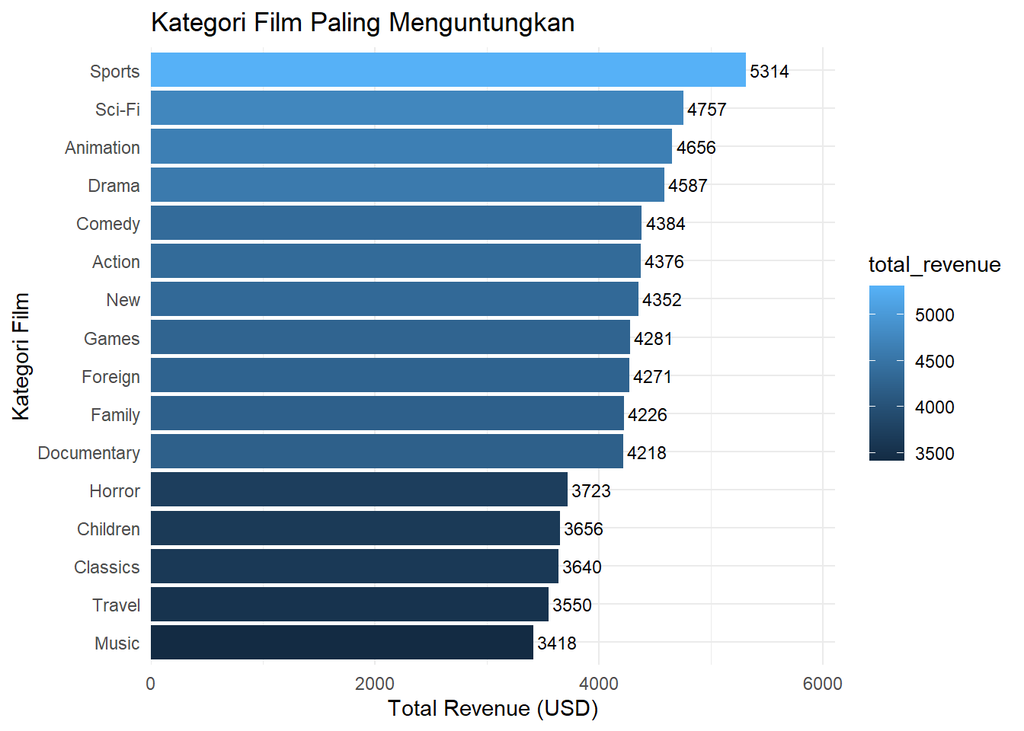

```r
ggplot(
  film_profit,
  aes(
    x    = reorder(kategori, total_revenue),
    y    = total_revenue,
    fill = total_revenue
  )
) +
geom_bar(stat = "identity") +
coord_flip() +
geom_text(
  aes(label = round(total_revenue, 0)),
  hjust = -0.1,
  size  = 3
) +
scale_y_continuous(expand = expansion(mult = c(0, 0.15))) +
labs(
  title = "Kategori Film Paling Menguntungkan",
  x     = "Kategori Film",
  y     = "Total Revenue (USD)"
) +
theme_minimal()
```

## 6.2 Interpretasi Bar Chart

Berdasarkan bar chart di atas, kategori **Sports** merupakan kategori film paling menguntungkan dengan total revenue tertinggi sebesar **$5314**, diikuti oleh **Sci-Fi** ($4757) dan **Animation** ($4656). Kategori **Drama** ($4587) dan **Comedy** ($4384) juga termasuk dalam kelompok lima besar penyumbang revenue tertinggi.

Kategori dengan revenue terendah adalah **Music** ($3418), diikuti **Travel** ($3550) dan **Classics** ($3640). Ketiga kategori ini secara konsisten berada di bawah rata-rata revenue keseluruhan sebesar **$4213**.

Secara keseluruhan, selisih antara kategori tertinggi (Sports, $5314) dan terendah (Music, $3418) hanya sekitar **$1896**, yang menunjukkan distribusi pendapatan yang relatif merata di antara seluruh 16 kategori film.

## 6.3 Pie Chart Distribusi Revenue

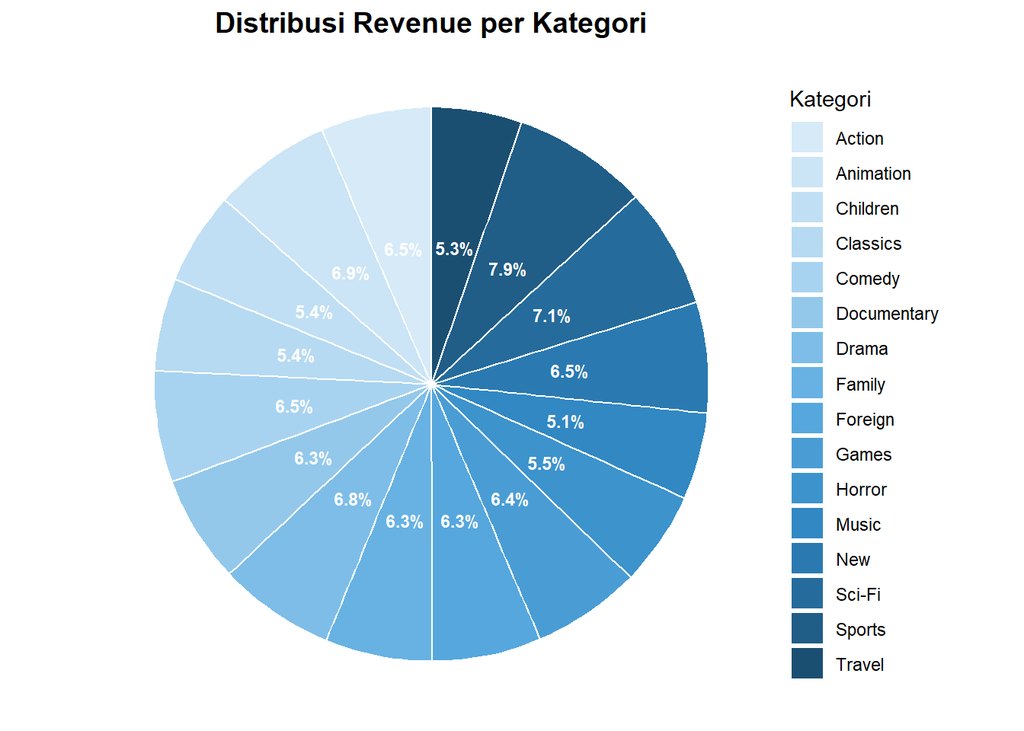

```r
film_profit %>%
  mutate(
    persen = total_revenue / sum(total_revenue) * 100,
    label  = paste0(round(persen, 1), "%")
  ) %>%
  ggplot(aes(x = "", y = persen, fill = kategori)) +

  geom_bar(
    stat = "identity",
    width = 1,
    color = "white"
  ) +

  coord_polar("y") +

  geom_text(
    aes(label = label),
    position = position_stack(vjust = 0.5),
    size = 3,
    color = "white",
    fontface = "bold"
  ) +

  scale_fill_manual(
    values = colorRampPalette(c(
      "#D6EAF8",
      "#AED6F1",
      "#5DADE2",
      "#2E86C1",
      "#1B4F72"
    ))(16)
  ) +

  theme_void() +

  labs(
    title = "Distribusi Revenue per Kategori",
    fill = "Kategori"
  ) +

  theme(
    plot.title = element_text(
      hjust = 0.5,
      face = "bold",
      size = 14
    ),

    legend.position = "right"
  )
```

## 6.4 Interpretasi Pie Chart

Pie chart menunjukkan bahwa distribusi revenue antar 16 kategori film sangat merata, dengan masing-masing kategori berkontribusi antara **5,1% hingga 7,9%** dari total pendapatan.

Selisih antara porsi terbesar dan terkecil hanya **2,8 poin persentase**, yang mengonfirmasi bahwa tidak ada satu kategori pun yang mendominasi secara signifikan. Bisnis rental ini memiliki portofolio pendapatan yang sangat seimbang dan tidak bergantung pada satu kategori tertentu.

## 6.5 Line Chart Jumlah Rental

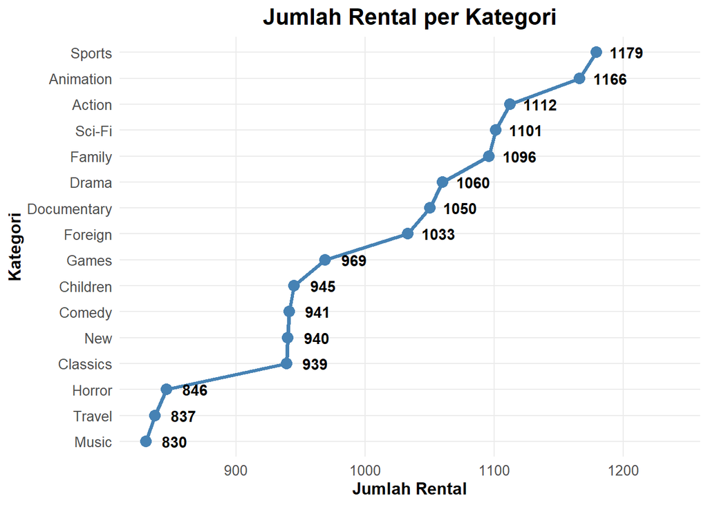

```r
ggplot(
  film_profit,
  aes(
    x = reorder(kategori, jumlah_rental),
    y = jumlah_rental,
    group = 1
  )
) +

geom_line(
  linewidth = 1.3,
  color = "steelblue"
) +

geom_point(
  size = 3.5,
  color = "steelblue"
) +

geom_text(
  aes(label = format(jumlah_rental, big.mark = ".")),
  hjust = -0.4,
  size = 3.8,
  fontface = "bold",
  color = "black"
) +

coord_flip() +

expand_limits(
  y = max(film_profit$jumlah_rental) + 60
) +

labs(
  title = "Jumlah Rental per Kategori",
  x = "Kategori",
  y = "Jumlah Rental"
) +

theme_minimal() +

theme(
  plot.title = element_text(
    size = 16,
    face = "bold",
    hjust = 0.5
  ),

  axis.title = element_text(
    size = 12,
    face = "bold"
  ),

  axis.text = element_text(
    size = 10
  ),

  panel.grid.minor = element_blank()
)
```

## 6.6 Interpretasi Line Chart

Line chart menunjukkan bahwa **Sports** merupakan kategori dengan jumlah rental terbanyak (1179 rental), diikuti **Animation** (1166) dan **Action** (1112). Ketiga kategori ini membentuk kelompok teratas dengan jumlah rental di atas 1100.

Kelompok menengah terdiri dari **Sci-Fi** (1.101), **Family** (1096), **Drama** (1060), **Documentary** (1050), dan **Foreign** (1033), yang berada di kisaran 1000–1110 rental.

Kategori **Music** memiliki jumlah rental paling sedikit (830), diikuti **Travel** (837) dan **Horror** (846). Terdapat *gap* yang cukup mencolok antara kelompok bawah ini dengan kelompok tengah — loncatan dari **Horror** (846) ke **Classics** (939) mencapai sekitar **93 rental**, yang terlihat sebagai lekukan tajam pada grafik.

Pola ini secara umum konsisten dengan hasil bar chart revenue. Namun terdapat pengecualian menarik pada kategori **Comedy** — meskipun jumlah rentalnya tergolong rendah (941, peringkat ke-11 dari 16), Comedy tetap menghasilkan revenue tinggi ($4384, peringkat ke-5), yang didukung oleh rata-rata pembayaran per rental tertinggi ($4,66) di antara seluruh kategori.

# 7 ANALISIS DAN INSIGHT

## 7.1 Statistik Deskriptif

```r
summary(film_profit)
```

```
##    kategori         jumlah_rental  total_revenue  rata_pembayaran
##  Length:16          Min.   : 830   Min.   :3418   Min.   :3.860
##  Class :character   1st Qu.: 940   1st Qu.:3706   1st Qu.:3.978
##  Mode  :character   Median : 969   Median :4276   Median :4.185
##                     Mean   :1002   Mean   :4213   Mean   :4.207
##                     3rd Qu.:1096   3rd Qu.:4435   3rd Qu.:4.405
##                     Max.   :1179   Max.   :5314   Max.   :4.660
```

```r
film_profit %>%
  summarise(
    rata_revenue   = mean(total_revenue),
    median_revenue = median(total_revenue),
    sd_revenue     = sd(total_revenue),
    min_revenue    = min(total_revenue),
    max_revenue    = max(total_revenue),
    rata_rental    = mean(as.numeric(jumlah_rental)),
    median_rental  = median(as.numeric(jumlah_rental)),
    sd_rental      = sd(as.numeric(jumlah_rental)),
    min_rental     = min(as.numeric(jumlah_rental)),
    max_rental     = max(as.numeric(jumlah_rental))
  )
```

```
##   rata_revenue median_revenue sd_revenue min_revenue max_revenue rata_rental
## 1      4212.91           4276   508.6516     3417.72     5314.21     1002.75
##   median_rental sd_rental min_rental max_rental
## 1          1001  113.3134        830       1179
```

## 7.2 Analisis Korelasi

```r
cor_result <- cor.test(
  as.numeric(film_profit$jumlah_rental),
  film_profit$total_revenue
)

cor_result
```

```
##
##  Pearson's product-moment correlation
##
## data:  as.numeric(film_profit$jumlah_rental) and film_profit$total_revenue
## t = 6.0038, df = 14, p-value = 3.233e-05
## alternative hypothesis: true correlation is not equal to 0
## 95 percent confidence interval:
##  0.6093066 0.9462868
## sample estimates:
##       cor
## 0.8486797
```

## 7.3 Analisis Data

Berdasarkan hasil statistik deskriptif, rata-rata revenue keseluruhan adalah **$4212,91** dengan median **$4276** dan standar deviasi **$508,65**. Nilai standar deviasi yang relatif kecil dibandingkan rata-rata mengonfirmasi bahwa distribusi revenue antar kategori memang merata.

Kategori **Sports** mendominasi baik dari sisi total revenue ($5314) maupun jumlah rental (1179), menjadikannya kategori paling menguntungkan secara keseluruhan.

Hasil uji korelasi Pearson menunjukkan nilai **r = 0,849** dengan **p-value = 3,233 × 10⁻⁵** (jauh di bawah α = 0,05), yang berarti terdapat **korelasi positif yang kuat dan signifikan secara statistik** antara jumlah rental dan total revenue. Interval kepercayaan 95% berada pada rentang **0,609–0,946**, semakin memperkuat kesimpulan bahwa hubungan ini bukan terjadi secara kebetulan.

Satu temuan menarik adalah kategori **Comedy** — meskipun jumlah rentalnya hanya 941 (peringkat ke-11), Comedy memiliki rata-rata pembayaran per rental tertinggi ($4,66), mendorong total revenuenya tetap kompetitif di posisi ke-5 ($4384). Ini menunjukkan bahwa jumlah rental bukan satu-satunya penentu revenue.

## 7.4 Insight Bisnis

Berdasarkan hasil analisis data, terdapat beberapa insight bisnis yang dapat dijadikan acuan pengambilan keputusan:

1. **Prioritaskan kategori Sports, Sci-Fi, dan Animation** — ketiga kategori ini konsisten unggul baik di revenue maupun jumlah rental. Sports mencatat revenue tertinggi ($5314) dengan 1179 rental, Animation mencatat ($4656) dengan 1166 rental, dan Sci-Fi menghasilkan ($4757) dengan 1101 rental. Penambahan stok dan variasi judul pada kategori ini berpotensi meningkatkan pendapatan lebih lanjut.
2. **Maksimalkan potensi kategori Comedy dan New** — Comedy hanya memiliki 941 rental (peringkat ke-11) namun menghasilkan revenue $4384 berkat rata-rata pembayaran tertinggi ($4,66 per rental). Demikian pula New ($4,63 per rental). Strategi pemasaran yang meningkatkan frekuensi penyewaan kedua kategori ini dapat mendongkrak revenue secara signifikan tanpa perlu menambah banyak stok.
3. **Berikan promosi khusus untuk kategori bawah (Music, Travel, Horror)** — ketiga kategori ini memiliki jumlah rental terendah (830, 837, dan 846). Program diskon, bundling, atau rekomendasi aktif kepada pelanggan dapat membantu mendongkrak minat penyewaan pada kategori-kategori ini.
4. **Pertahankan keseimbangan portofolio** — distribusi revenue yang sangat merata (5,1–7,9% per kategori, selisih hanya 2,8 poin persentase) merupakan indikator positif bahwa bisnis tidak bergantung pada satu kategori saja. Strategi diversifikasi ini perlu dipertahankan agar risiko bisnis tetap terkelola dengan baik.

# 8 PERSAMAAN LATEX

## 8.1 Rumus Rata-rata Revenue

$$\bar{x} = \frac{\sum x}{n}$$

Keterangan:

- $\bar{x}$ = rata-rata revenue
- $\sum x$ = total revenue
- $n$ = jumlah kategori film

Persamaan tersebut digunakan untuk menghitung rata-rata pendapatan pada setiap kategori film.

## 8.2 Rumus Korelasi Pearson

$$r = \frac{\sum_{i=1}^{n}(x_i - \bar{x})(y_i - \bar{y})}
{\sqrt{\sum_{i=1}^{n}(x_i - \bar{x})^2 \cdot
\sum_{i=1}^{n}(y_i - \bar{y})^2}}$$

- $r$ = koefisien korelasi Pearson
- $x_i$ = jumlah rental kategori ke-i
- $y_i$ = total revenue kategori ke-i
- $\bar{x}$ = rata-rata jumlah rental
- $\bar{y}$ = rata-rata total revenue

Persamaan korelasi Pearson digunakan untuk mengukur hubungan antara jumlah rental dan total revenue pada setiap kategori film.

## 8.3 Rumus Persentase Revenue

$$Persentase =
\frac{Revenue\ Kategori}
{Total\ Revenue}
\times 100\%$$

Persamaan tersebut digunakan untuk menghitung kontribusi revenue masing-masing kategori film terhadap total pendapatan perusahaan.

# 9 KESIMPULAN

Berdasarkan hasil analisis database Sakila terhadap 16 kategori film, dapat disimpulkan bahwa kategori **Sports** merupakan kategori film paling menguntungkan dengan total revenue tertinggi sebesar **$5314** dan jumlah rental terbanyak sebesar **1179 transaksi**.

Hasil uji korelasi Pearson menunjukkan hubungan positif yang kuat (**r = 0,849, p = 3,233 × 10⁻⁵**) antara jumlah rental dan total revenue, mengonfirmasi bahwa frekuensi penyewaan merupakan faktor utama penentu pendapatan.

Distribusi revenue antar 16 kategori terbilang sangat merata, dengan kontribusi masing-masing kategori berkisar antara **5,1–7,9%** dari total pendapatan. Selisih antara kategori teratas (Sports, $5314) dan terbawah (Music, $3418) hanya sekitar **$1896**, menunjukkan fondasi pendapatan bisnis yang stabil dan terdiversifikasi.

Temuan menarik adalah kategori **Comedy** yang meskipun jumlah rentalnya tergolong rendah (941), memiliki rata-rata pembayaran per rental tertinggi ($4,66) sehingga revenue totalnya tetap kompetitif di posisi ke-5. Hal ini menunjukkan bahwa strategi harga juga berperan penting selain volume penyewaan.

Perusahaan disarankan untuk: (1) memprioritaskan stok pada kategori **Sports, Sci-Fi, dan Animation** yang dominan di kedua metrik; (2) mengoptimalkan strategi pemasaran **Comedy dan New** untuk meningkatkan frekuensi rental mengingat nilai pembayaran per rentalnya yang tinggi; serta (3) memberikan program promosi khusus untuk kategori **Music, Travel, dan Horror** guna meningkatkan performa kategori-kategori tersebut.

# 10 PENUTUP

## 10.1 Menutup Koneksi Database

```r
dbDisconnect(con)
```